# Risk Factor Analysis

## Outcome Variable

**Outcome Variable:** stunted

## Predictor Variables

**Intervention Variable:** exclfeed36

**Adjustment Set:**

- arm
- sex
- W_mage
- meducyrs
- feducyrs
- hhwealth_quart
- hfoodsec
- W_mhtcm
- vagbrth
- W_gagebrth
- W_birthwt
- W_birthlen
- W_nrooms
- W_nchldlt5
- month
- brthmon
- W_parity
- impfloor
- impsan
- safeh20
- delta_W_mage
- delta_meducyrs
- delta_feducyrs
- delta_hhwealth_quart
- delta_hfoodsec
- delta_W_mhtcm
- delta_vagbrth
- delta_W_gagebrth
- delta_W_birthwt
- delta_W_birthlen
- delta_W_nrooms
- delta_W_nchldlt5
- delta_month
- delta_brthmon
- delta_W_parity
- delta_impfloor
- delta_impsan
- delta_safeh20

## Stratifying Variables

The analysis was stratified on these variable(s):

- agecat
- studyid
- country

## Data Summary

| agecat | studyid | country | exclfeed36 | stunted | n_cell | n |
| --- | --- | --- | --- | --- | --- | --- |
| Birth | ki0047075b-MAL-ED | BANGLADESH | 0 | 0 | 151 | 243 |
| Birth | ki0047075b-MAL-ED | BANGLADESH | 0 | 1 | 30 | 243 |
| Birth | ki0047075b-MAL-ED | BANGLADESH | 1 | 0 | 51 | 243 |
| Birth | ki0047075b-MAL-ED | BANGLADESH | 1 | 1 | 11 | 243 |
| Birth | ki0047075b-MAL-ED | BRAZIL | 0 | 0 | 156 | 185 |
| Birth | ki0047075b-MAL-ED | BRAZIL | 0 | 1 | 16 | 185 |
| Birth | ki0047075b-MAL-ED | BRAZIL | 1 | 0 | 10 | 185 |
| Birth | ki0047075b-MAL-ED | BRAZIL | 1 | 1 | 3 | 185 |
| Birth | ki0047075b-MAL-ED | INDIA | 0 | 0 | 164 | 198 |
| Birth | ki0047075b-MAL-ED | INDIA | 0 | 1 | 29 | 198 |
| Birth | ki0047075b-MAL-ED | INDIA | 1 | 0 | 2 | 198 |
| Birth | ki0047075b-MAL-ED | INDIA | 1 | 1 | 3 | 198 |
| Birth | ki0047075b-MAL-ED | NEPAL | 0 | 0 | 143 | 172 |
| Birth | ki0047075b-MAL-ED | NEPAL | 0 | 1 | 18 | 172 |
| Birth | ki0047075b-MAL-ED | NEPAL | 1 | 0 | 11 | 172 |
| Birth | ki0047075b-MAL-ED | NEPAL | 1 | 1 | 0 | 172 |
| Birth | ki0047075b-MAL-ED | PERU | 0 | 0 | 228 | 273 |
| Birth | ki0047075b-MAL-ED | PERU | 0 | 1 | 30 | 273 |
| Birth | ki0047075b-MAL-ED | PERU | 1 | 0 | 13 | 273 |
| Birth | ki0047075b-MAL-ED | PERU | 1 | 1 | 2 | 273 |
| Birth | ki0047075b-MAL-ED | SOUTH AFRICA | 0 | 0 | 212 | 236 |
| Birth | ki0047075b-MAL-ED | SOUTH AFRICA | 0 | 1 | 24 | 236 |
| Birth | ki0047075b-MAL-ED | SOUTH AFRICA | 1 | 0 | 0 | 236 |
| Birth | ki0047075b-MAL-ED | SOUTH AFRICA | 1 | 1 | 0 | 236 |
| Birth | ki0047075b-MAL-ED | TANZANIA, UNITED REPUBLIC OF | 0 | 0 | 102 | 121 |
| Birth | ki0047075b-MAL-ED | TANZANIA, UNITED REPUBLIC OF | 0 | 1 | 18 | 121 |
| Birth | ki0047075b-MAL-ED | TANZANIA, UNITED REPUBLIC OF | 1 | 0 | 1 | 121 |
| Birth | ki0047075b-MAL-ED | TANZANIA, UNITED REPUBLIC OF | 1 | 1 | 0 | 121 |
| Birth | ki1000108-CMC-V-BCS-2002 | INDIA | 0 | 0 | 0 | 3 |
| Birth | ki1000108-CMC-V-BCS-2002 | INDIA | 0 | 1 | 0 | 3 |

[output cut: 150 more lines]

The following strata were considered:

- agecat: 24 months, studyid: ki0047075b-MAL-ED, country: BANGLADESH
- agecat: 24 months, studyid: ki0047075b-MAL-ED, country: BRAZIL
- agecat: 24 months, studyid: ki0047075b-MAL-ED, country: INDIA
- agecat: 24 months, studyid: ki0047075b-MAL-ED, country: NEPAL
- agecat: 24 months, studyid: ki0047075b-MAL-ED, country: PERU
- agecat: 24 months, studyid: ki0047075b-MAL-ED, country: SOUTH AFRICA
- agecat: 24 months, studyid: ki0047075b-MAL-ED, country: TANZANIA, UNITED REPUBLIC OF
- agecat: 24 months, studyid: ki1000108-CMC-V-BCS-2002, country: INDIA
- agecat: 24 months, studyid: ki1000108-IRC, country: INDIA
- agecat: 24 months, studyid: ki1017093b-PROVIDE, country: BANGLADESH
- agecat: 24 months, studyid: ki1101329-Keneba, country: GAMBIA
- agecat: 24 months, studyid: ki1113344-GMS-Nepal, country: NEPAL
- agecat: 24 months, studyid: ki1148112-LCNI-5, country: MALAWI
- agecat: 24 months, studyid: kiGH5241-JiVitA-3, country: BANGLADESH
- agecat: 24 months, studyid: kiGH5241-JiVitA-4, country: BANGLADESH
- agecat: 6 months, studyid: ki0047075b-MAL-ED, country: BANGLADESH
- agecat: 6 months, studyid: ki0047075b-MAL-ED, country: BRAZIL
- agecat: 6 months, studyid: ki0047075b-MAL-ED, country: INDIA
- agecat: 6 months, studyid: ki0047075b-MAL-ED, country: NEPAL
- agecat: 6 months, studyid: ki0047075b-MAL-ED, country: PERU
- agecat: 6 months, studyid: ki0047075b-MAL-ED, country: SOUTH AFRICA
- agecat: 6 months, studyid: ki0047075b-MAL-ED, country: TANZANIA, UNITED REPUBLIC OF
- agecat: 6 months, studyid: ki1000108-CMC-V-BCS-2002, country: INDIA
- agecat: 6 months, studyid: ki1000108-IRC, country: INDIA
- agecat: 6 months, studyid: ki1000109-EE, country: PAKISTAN
- agecat: 6 months, studyid: ki1000304b-SAS-FoodSuppl, country: INDIA
- agecat: 6 months, studyid: ki1017093b-PROVIDE, country: BANGLADESH
- agecat: 6 months, studyid: ki1101329-Keneba, country: GAMBIA
- agecat: 6 months, studyid: ki1113344-GMS-Nepal, country: NEPAL
- agecat: 6 months, studyid: ki1148112-LCNI-5, country: MALAWI
- agecat: 6 months, studyid: kiGH5241-JiVitA-3, country: BANGLADESH
- agecat: 6 months, studyid: kiGH5241-JiVitA-4, country: BANGLADESH
- agecat: Birth, studyid: ki0047075b-MAL-ED, country: BANGLADESH
- agecat: Birth, studyid: ki0047075b-MAL-ED, country: BRAZIL
- agecat: Birth, studyid: ki0047075b-MAL-ED, country: INDIA
- agecat: Birth, studyid: ki0047075b-MAL-ED, country: NEPAL
- agecat: Birth, studyid: ki0047075b-MAL-ED, country: PERU
- agecat: Birth, studyid: ki0047075b-MAL-ED, country: SOUTH AFRICA
- agecat: Birth, studyid: ki0047075b-MAL-ED, country: TANZANIA, UNITED REPUBLIC OF
- agecat: Birth, studyid: ki1000108-CMC-V-BCS-2002, country: INDIA
- agecat: Birth, studyid: ki1000108-IRC, country: INDIA
- agecat: Birth, studyid: ki1000109-EE, country: PAKISTAN
- agecat: Birth, studyid: ki1101329-Keneba, country: GAMBIA
- agecat: Birth, studyid: kiGH5241-JiVitA-3, country: BANGLADESH
- agecat: Birth, studyid: kiGH5241-JiVitA-4, country: BANGLADESH

### Dropped Strata

Some strata were dropped due to rare outcomes:

- agecat: Birth, studyid: ki0047075b-MAL-ED, country: BRAZIL
- agecat: Birth, studyid: ki0047075b-MAL-ED, country: INDIA
- agecat: Birth, studyid: ki0047075b-MAL-ED, country: NEPAL
- agecat: Birth, studyid: ki0047075b-MAL-ED, country: PERU
- agecat: Birth, studyid: ki0047075b-MAL-ED, country: SOUTH AFRICA
- agecat: Birth, studyid: ki0047075b-MAL-ED, country: TANZANIA, UNITED REPUBLIC OF
- agecat: Birth, studyid: ki1000108-CMC-V-BCS-2002, country: INDIA
- agecat: Birth, studyid: ki1000108-IRC, country: INDIA
- agecat: Birth, studyid: ki1000109-EE, country: PAKISTAN
- agecat: 6 months, studyid: ki0047075b-MAL-ED, country: BRAZIL
- agecat: 6 months, studyid: ki0047075b-MAL-ED, country: INDIA
- agecat: 6 months, studyid: ki0047075b-MAL-ED, country: NEPAL
- agecat: 6 months, studyid: ki0047075b-MAL-ED, country: PERU
- agecat: 6 months, studyid: ki0047075b-MAL-ED, country: SOUTH AFRICA
- agecat: 6 months, studyid: ki0047075b-MAL-ED, country: TANZANIA, UNITED REPUBLIC OF
- agecat: 6 months, studyid: ki1000108-CMC-V-BCS-2002, country: INDIA
- agecat: 6 months, studyid: ki1000108-IRC, country: INDIA
- agecat: 6 months, studyid: ki1000304b-SAS-FoodSuppl, country: INDIA
- agecat: 24 months, studyid: ki0047075b-MAL-ED, country: BRAZIL
- agecat: 24 months, studyid: ki0047075b-MAL-ED, country: INDIA
- agecat: 24 months, studyid: ki0047075b-MAL-ED, country: NEPAL
- agecat: 24 months, studyid: ki0047075b-MAL-ED, country: SOUTH AFRICA
- agecat: 24 months, studyid: ki0047075b-MAL-ED, country: TANZANIA, UNITED REPUBLIC OF
- agecat: 24 months, studyid: ki1000108-CMC-V-BCS-2002, country: INDIA
- agecat: 24 months, studyid: ki1000108-IRC, country: INDIA

## Methods Detail

We’re interested in the causal parameters $E[Y_a]$ for all values of $a \in \mathcal{A}$. These parameters represent the mean outcome if, possibly contrary to fact, we intervened to set all units to have $A=a$. Under the randomization and positivity assumptions, these are identified by the statistical parameters $\psi_a=E_W[E_{Y|A,W}(Y|A=a,W)]$. In addition, we’re interested in the mean of $Y$, $E[Y]$ under no intervention (the observed mean). We will estimate these parameters by using SuperLearner to fit the relevant likelihood factors – $E_{Y|A,W}(Y|A=a,W)$ and $p(A=a|W)$, and then updating our likelihood fit using a joint TMLE.

For unadjusted analyses ($W=\{\}$), initial likelihoods were estimated using Lrnr_glm to estimate the simple $E(Y|A)$ and Lrnr_mean to estimate $p(A)$. For adjusted analyses, a small library containing Lrnr_glmnet, Lrnr_xgboost, and Lrnr_mean was used.

Having estimated these parameters, we will then use the delta method to estimate relative risks and attributable risks relative to a prespecified baseline level of $A$.

# Results Detail

## Results Plots

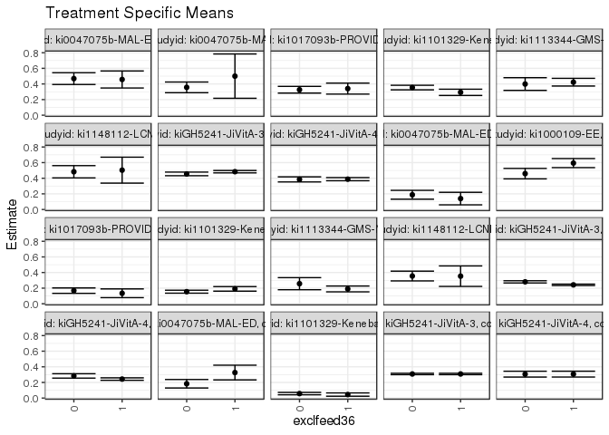

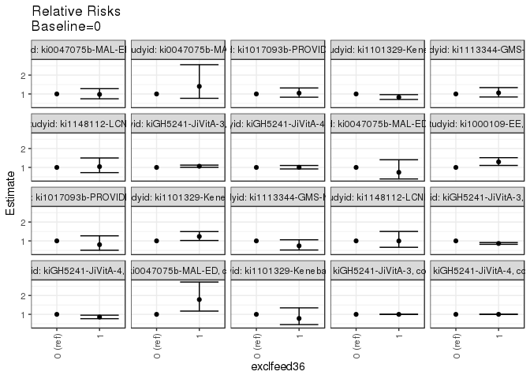

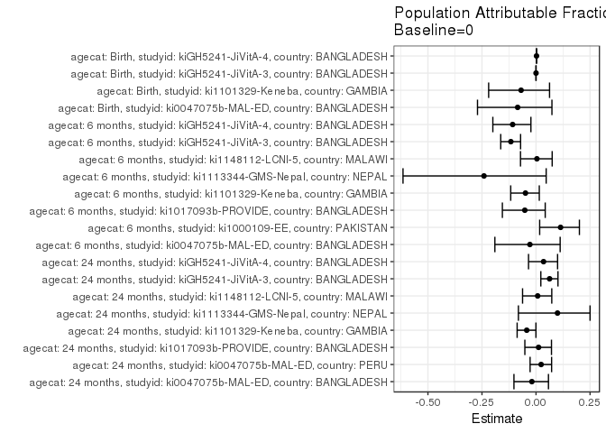

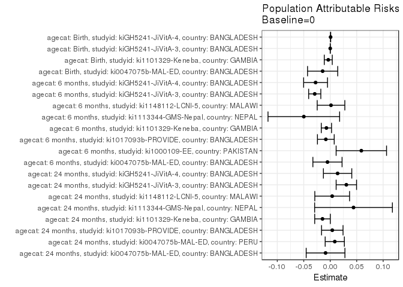

## Results Table

### Parameter: TSM

| agecat | studyid | country | intervention_level | baseline_level | estimate | ci_lower | ci_upper |
| --- | --- | --- | --- | --- | --- | --- | --- |
| Birth | ki0047075b-MAL-ED | BANGLADESH | 0 | NA | 0.1830639 | 0.1288349 | 0.2372930 |
| Birth | ki0047075b-MAL-ED | BANGLADESH | 1 | NA | 0.3264596 | 0.2323719 | 0.4205472 |
| Birth | ki1101329-Keneba | GAMBIA | 0 | NA | 0.0572091 | 0.0419713 | 0.0724470 |
| Birth | ki1101329-Keneba | GAMBIA | 1 | NA | 0.0448078 | 0.0237310 | 0.0658846 |
| Birth | kiGH5241-JiVitA-3 | BANGLADESH | 0 | NA | 0.3083939 | 0.2997244 | 0.3170635 |
| Birth | kiGH5241-JiVitA-3 | BANGLADESH | 1 | NA | 0.3083916 | 0.2997210 | 0.3170622 |
| Birth | kiGH5241-JiVitA-4 | BANGLADESH | 0 | NA | 0.3060300 | 0.2688277 | 0.3432322 |
| Birth | kiGH5241-JiVitA-4 | BANGLADESH | 1 | NA | 0.3066595 | 0.2694039 | 0.3439152 |
| 6 months | ki0047075b-MAL-ED | BANGLADESH | 0 | NA | 0.1885279 | 0.1318262 | 0.2452297 |
| 6 months | ki0047075b-MAL-ED | BANGLADESH | 1 | NA | 0.1396073 | 0.0593286 | 0.2198859 |
| 6 months | ki1000109-EE | PAKISTAN | 0 | NA | 0.4589231 | 0.3918805 | 0.5259657 |
| 6 months | ki1000109-EE | PAKISTAN | 1 | NA | 0.5941110 | 0.5361275 | 0.6520945 |
| 6 months | ki1017093b-PROVIDE | BANGLADESH | 0 | NA | 0.1680849 | 0.1334679 | 0.2027018 |
| 6 months | ki1017093b-PROVIDE | BANGLADESH | 1 | NA | 0.1343596 | 0.0784530 | 0.1902662 |
| 6 months | ki1101329-Keneba | GAMBIA | 0 | NA | 0.1546923 | 0.1355553 | 0.1738293 |
| 6 months | ki1101329-Keneba | GAMBIA | 1 | NA | 0.1909222 | 0.1615997 | 0.2202448 |
| 6 months | ki1113344-GMS-Nepal | NEPAL | 0 | NA | 0.2571059 | 0.1798331 | 0.3343787 |
| 6 months | ki1113344-GMS-Nepal | NEPAL | 1 | NA | 0.1900183 | 0.1527796 | 0.2272570 |
| 6 months | ki1148112-LCNI-5 | MALAWI | 0 | NA | 0.3551296 | 0.2925989 | 0.4176604 |
| 6 months | ki1148112-LCNI-5 | MALAWI | 1 | NA | 0.3534705 | 0.2224470 | 0.4844940 |
| 6 months | kiGH5241-JiVitA-3 | BANGLADESH | 0 | NA | 0.2806976 | 0.2664743 | 0.2949210 |
| 6 months | kiGH5241-JiVitA-3 | BANGLADESH | 1 | NA | 0.2422704 | 0.2331937 | 0.2513472 |
| 6 months | kiGH5241-JiVitA-4 | BANGLADESH | 0 | NA | 0.2834908 | 0.2554673 | 0.3115144 |
| 6 months | kiGH5241-JiVitA-4 | BANGLADESH | 1 | NA | 0.2430383 | 0.2273422 | 0.2587344 |
| 24 months | ki0047075b-MAL-ED | BANGLADESH | 0 | NA | 0.4685266 | 0.3932034 | 0.5438498 |
| 24 months | ki0047075b-MAL-ED | BANGLADESH | 1 | NA | 0.4573871 | 0.3482524 | 0.5665217 |
| 24 months | ki0047075b-MAL-ED | PERU | 0 | NA | 0.3563830 | 0.2877505 | 0.4250155 |
| 24 months | ki0047075b-MAL-ED | PERU | 1 | NA | 0.5000000 | 0.2163937 | 0.7836063 |
| 24 months | ki1017093b-PROVIDE | BANGLADESH | 0 | NA | 0.3259548 | 0.2830121 | 0.3688975 |
| 24 months | ki1017093b-PROVIDE | BANGLADESH | 1 | NA | 0.3405501 | 0.2702481 | 0.4108522 |
| 24 months | ki1101329-Keneba | GAMBIA | 0 | NA | 0.3538894 | 0.3246595 | 0.3831192 |
| 24 months | ki1101329-Keneba | GAMBIA | 1 | NA | 0.2928386 | 0.2528425 | 0.3328346 |
| 24 months | ki1113344-GMS-Nepal | NEPAL | 0 | NA | 0.3989658 | 0.3177319 | 0.4801997 |
| 24 months | ki1113344-GMS-Nepal | NEPAL | 1 | NA | 0.4227639 | 0.3733015 | 0.4722262 |
| 24 months | ki1148112-LCNI-5 | MALAWI | 0 | NA | 0.4830667 | 0.4046234 | 0.5615100 |
| 24 months | ki1148112-LCNI-5 | MALAWI | 1 | NA | 0.5035625 | 0.3375129 | 0.6696121 |
| 24 months | kiGH5241-JiVitA-3 | BANGLADESH | 0 | NA | 0.4552635 | 0.4320324 | 0.4784946 |
| 24 months | kiGH5241-JiVitA-3 | BANGLADESH | 1 | NA | 0.4839808 | 0.4688152 | 0.4991465 |
| 24 months | kiGH5241-JiVitA-4 | BANGLADESH | 0 | NA | 0.3852801 | 0.3525937 | 0.4179665 |
| 24 months | kiGH5241-JiVitA-4 | BANGLADESH | 1 | NA | 0.3881113 | 0.3681818 | 0.4080408 |

### Parameter: E(Y)

| agecat | studyid | country | intervention_level | baseline_level | estimate | ci_lower | ci_upper |
| --- | --- | --- | --- | --- | --- | --- | --- |
| Birth | ki0047075b-MAL-ED | BANGLADESH | NA | NA | 0.1687243 | 0.1215395 | 0.2159090 |
| Birth | ki1101329-Keneba | GAMBIA | NA | NA | 0.0535144 | 0.0410431 | 0.0659857 |
| Birth | kiGH5241-JiVitA-3 | BANGLADESH | NA | NA | 0.3084038 | 0.2997331 | 0.3170746 |
| Birth | kiGH5241-JiVitA-4 | BANGLADESH | NA | NA | 0.3067400 | 0.2694794 | 0.3440006 |
| 6 months | ki0047075b-MAL-ED | BANGLADESH | NA | NA | 0.1833333 | 0.1342773 | 0.2323893 |
| 6 months | ki1000109-EE | PAKISTAN | NA | NA | 0.5177112 | 0.4665188 | 0.5689035 |
| 6 months | ki1017093b-PROVIDE | BANGLADESH | NA | NA | 0.1597938 | 0.1299995 | 0.1895881 |
| 6 months | ki1101329-Keneba | GAMBIA | NA | NA | 0.1474860 | 0.1310548 | 0.1639172 |
| 6 months | ki1113344-GMS-Nepal | NEPAL | NA | NA | 0.2072243 | 0.1725535 | 0.2418951 |
| 6 months | ki1148112-LCNI-5 | MALAWI | NA | NA | 0.3566176 | 0.2995882 | 0.4136471 |
| 6 months | kiGH5241-JiVitA-3 | BANGLADESH | NA | NA | 0.2514393 | 0.2427410 | 0.2601375 |
| 6 months | kiGH5241-JiVitA-4 | BANGLADESH | NA | NA | 0.2558140 | 0.2405969 | 0.2710310 |
| 24 months | ki0047075b-MAL-ED | BANGLADESH | NA | NA | 0.4597156 | 0.3923103 | 0.5271210 |
| 24 months | ki0047075b-MAL-ED | PERU | NA | NA | 0.3650000 | 0.2981110 | 0.4318890 |
| 24 months | ki1017093b-PROVIDE | BANGLADESH | NA | NA | 0.3298611 | 0.2914318 | 0.3682904 |
| 24 months | ki1101329-Keneba | GAMBIA | NA | NA | 0.3393113 | 0.3144474 | 0.3641753 |
| 24 months | ki1113344-GMS-Nepal | NEPAL | NA | NA | 0.4429825 | 0.3973399 | 0.4886250 |
| 24 months | ki1148112-LCNI-5 | MALAWI | NA | NA | 0.4867725 | 0.4153250 | 0.5582200 |
| 24 months | kiGH5241-JiVitA-3 | BANGLADESH | NA | NA | 0.4857314 | 0.4714029 | 0.5000599 |
| 24 months | kiGH5241-JiVitA-4 | BANGLADESH | NA | NA | 0.3992046 | 0.3802350 | 0.4181742 |

### Parameter: RR

| agecat | studyid | country | intervention_level | baseline_level | estimate | ci_lower | ci_upper |
| --- | --- | --- | --- | --- | --- | --- | --- |
| Birth | ki0047075b-MAL-ED | BANGLADESH | 0 | 0 | 1.0000000 | 1.0000000 | 1.0000000 |
| Birth | ki0047075b-MAL-ED | BANGLADESH | 1 | 0 | 1.7833091 | 1.1722132 | 2.7129802 |
| Birth | ki1101329-Keneba | GAMBIA | 0 | 0 | 1.0000000 | 1.0000000 | 1.0000000 |
| Birth | ki1101329-Keneba | GAMBIA | 1 | 0 | 0.7832277 | 0.4562949 | 1.3444061 |
| Birth | kiGH5241-JiVitA-3 | BANGLADESH | 0 | 0 | 1.0000000 | 1.0000000 | 1.0000000 |
| Birth | kiGH5241-JiVitA-3 | BANGLADESH | 1 | 0 | 0.9999925 | 0.9999436 | 1.0000415 |
| Birth | kiGH5241-JiVitA-4 | BANGLADESH | 0 | 0 | 1.0000000 | 1.0000000 | 1.0000000 |
| Birth | kiGH5241-JiVitA-4 | BANGLADESH | 1 | 0 | 1.0020572 | 1.0012110 | 1.0029042 |
| 6 months | ki0047075b-MAL-ED | BANGLADESH | 0 | 0 | 1.0000000 | 1.0000000 | 1.0000000 |
| 6 months | ki0047075b-MAL-ED | BANGLADESH | 1 | 0 | 0.7405124 | 0.3899099 | 1.4063724 |
| 6 months | ki1000109-EE | PAKISTAN | 0 | 0 | 1.0000000 | 1.0000000 | 1.0000000 |
| 6 months | ki1000109-EE | PAKISTAN | 1 | 0 | 1.2945763 | 1.1046109 | 1.5172110 |
| 6 months | ki1017093b-PROVIDE | BANGLADESH | 0 | 0 | 1.0000000 | 1.0000000 | 1.0000000 |
| 6 months | ki1017093b-PROVIDE | BANGLADESH | 1 | 0 | 0.7993556 | 0.5037327 | 1.2684690 |
| 6 months | ki1101329-Keneba | GAMBIA | 0 | 0 | 1.0000000 | 1.0000000 | 1.0000000 |
| 6 months | ki1101329-Keneba | GAMBIA | 1 | 0 | 1.2342066 | 1.0200017 | 1.4933954 |
| 6 months | ki1113344-GMS-Nepal | NEPAL | 0 | 0 | 1.0000000 | 1.0000000 | 1.0000000 |
| 6 months | ki1113344-GMS-Nepal | NEPAL | 1 | 0 | 0.7390662 | 0.5163533 | 1.0578394 |
| 6 months | ki1148112-LCNI-5 | MALAWI | 0 | 0 | 1.0000000 | 1.0000000 | 1.0000000 |
| 6 months | ki1148112-LCNI-5 | MALAWI | 1 | 0 | 0.9953282 | 0.6602999 | 1.5003457 |
| 6 months | kiGH5241-JiVitA-3 | BANGLADESH | 0 | 0 | 1.0000000 | 1.0000000 | 1.0000000 |
| 6 months | kiGH5241-JiVitA-3 | BANGLADESH | 1 | 0 | 0.8631012 | 0.8174766 | 0.9112722 |
| 6 months | kiGH5241-JiVitA-4 | BANGLADESH | 0 | 0 | 1.0000000 | 1.0000000 | 1.0000000 |
| 6 months | kiGH5241-JiVitA-4 | BANGLADESH | 1 | 0 | 0.8573057 | 0.7693189 | 0.9553557 |
| 24 months | ki0047075b-MAL-ED | BANGLADESH | 0 | 0 | 1.0000000 | 1.0000000 | 1.0000000 |
| 24 months | ki0047075b-MAL-ED | BANGLADESH | 1 | 0 | 0.9762244 | 0.7445431 | 1.2799985 |
| 24 months | ki0047075b-MAL-ED | PERU | 0 | 0 | 1.0000000 | 1.0000000 | 1.0000000 |
| 24 months | ki0047075b-MAL-ED | PERU | 1 | 0 | 1.4029851 | 0.7707342 | 2.5538857 |
| 24 months | ki1017093b-PROVIDE | BANGLADESH | 0 | 0 | 1.0000000 | 1.0000000 | 1.0000000 |
| 24 months | ki1017093b-PROVIDE | BANGLADESH | 1 | 0 | 1.0447772 | 0.8277163 | 1.3187602 |
| 24 months | ki1101329-Keneba | GAMBIA | 0 | 0 | 1.0000000 | 1.0000000 | 1.0000000 |
| 24 months | ki1101329-Keneba | GAMBIA | 1 | 0 | 0.8274862 | 0.7094482 | 0.9651632 |
| 24 months | ki1113344-GMS-Nepal | NEPAL | 0 | 0 | 1.0000000 | 1.0000000 | 1.0000000 |
| 24 months | ki1113344-GMS-Nepal | NEPAL | 1 | 0 | 1.0596493 | 0.8393317 | 1.3377984 |
| 24 months | ki1148112-LCNI-5 | MALAWI | 0 | 0 | 1.0000000 | 1.0000000 | 1.0000000 |
| 24 months | ki1148112-LCNI-5 | MALAWI | 1 | 0 | 1.0424286 | 0.7237310 | 1.5014659 |
| 24 months | kiGH5241-JiVitA-3 | BANGLADESH | 0 | 0 | 1.0000000 | 1.0000000 | 1.0000000 |
| 24 months | kiGH5241-JiVitA-3 | BANGLADESH | 1 | 0 | 1.0630785 | 1.0072077 | 1.1220485 |
| 24 months | kiGH5241-JiVitA-4 | BANGLADESH | 0 | 0 | 1.0000000 | 1.0000000 | 1.0000000 |
| 24 months | kiGH5241-JiVitA-4 | BANGLADESH | 1 | 0 | 1.0073484 | 0.9198715 | 1.1031442 |

### Parameter: PAR

| agecat | studyid | country | intervention_level | baseline_level | estimate | ci_lower | ci_upper |
| --- | --- | --- | --- | --- | --- | --- | --- |
| Birth | ki0047075b-MAL-ED | BANGLADESH | 0 | NA | -0.0143397 | -0.0428398 | 0.0141605 |
| Birth | ki1101329-Keneba | GAMBIA | 0 | NA | -0.0036948 | -0.0112510 | 0.0038615 |
| Birth | kiGH5241-JiVitA-3 | BANGLADESH | 0 | NA | 0.0000099 | -0.0000018 | 0.0000216 |
| Birth | kiGH5241-JiVitA-4 | BANGLADESH | 0 | NA | 0.0007101 | 0.0004950 | 0.0009252 |
| 6 months | ki0047075b-MAL-ED | BANGLADESH | 0 | NA | -0.0051946 | -0.0327662 | 0.0223769 |
| 6 months | ki1000109-EE | PAKISTAN | 0 | NA | 0.0587880 | 0.0111713 | 0.1064048 |
| 6 months | ki1017093b-PROVIDE | BANGLADESH | 0 | NA | -0.0082911 | -0.0241250 | 0.0075429 |
| 6 months | ki1101329-Keneba | GAMBIA | 0 | NA | -0.0072063 | -0.0169127 | 0.0025001 |
| 6 months | ki1113344-GMS-Nepal | NEPAL | 0 | NA | -0.0498816 | -0.1175320 | 0.0177688 |
| 6 months | ki1148112-LCNI-5 | MALAWI | 0 | NA | 0.0014880 | -0.0246044 | 0.0275804 |
| 6 months | kiGH5241-JiVitA-3 | BANGLADESH | 0 | NA | -0.0292584 | -0.0407327 | -0.0177840 |
| 6 months | kiGH5241-JiVitA-4 | BANGLADESH | 0 | NA | -0.0276769 | -0.0502210 | -0.0051327 |
| 24 months | ki0047075b-MAL-ED | BANGLADESH | 0 | NA | -0.0088109 | -0.0453914 | 0.0277696 |
| 24 months | ki0047075b-MAL-ED | PERU | 0 | NA | 0.0086170 | -0.0095205 | 0.0267546 |
| 24 months | ki1017093b-PROVIDE | BANGLADESH | 0 | NA | 0.0039063 | -0.0163942 | 0.0242068 |
| 24 months | ki1101329-Keneba | GAMBIA | 0 | NA | -0.0145780 | -0.0293162 | 0.0001601 |
| 24 months | ki1113344-GMS-Nepal | NEPAL | 0 | NA | 0.0440166 | -0.0294353 | 0.1174685 |
| 24 months | ki1148112-LCNI-5 | MALAWI | 0 | NA | 0.0037058 | -0.0291406 | 0.0365522 |
| 24 months | kiGH5241-JiVitA-3 | BANGLADESH | 0 | NA | 0.0304678 | 0.0111877 | 0.0497479 |
| 24 months | kiGH5241-JiVitA-4 | BANGLADESH | 0 | NA | 0.0139245 | -0.0128785 | 0.0407275 |

### Parameter: PAF

| agecat | studyid | country | intervention_level | baseline_level | estimate | ci_lower | ci_upper |
| --- | --- | --- | --- | --- | --- | --- | --- |
| Birth | ki0047075b-MAL-ED | BANGLADESH | 0 | NA | -0.0849887 | -0.2707086 | 0.0735874 |
| Birth | ki1101329-Keneba | GAMBIA | 0 | NA | -0.0690424 | -0.2191309 | 0.0625685 |
| Birth | kiGH5241-JiVitA-3 | BANGLADESH | 0 | NA | 0.0000322 | -0.0000057 | 0.0000701 |
| Birth | kiGH5241-JiVitA-4 | BANGLADESH | 0 | NA | 0.0023149 | 0.0016344 | 0.0029949 |
| 6 months | ki0047075b-MAL-ED | BANGLADESH | 0 | NA | -0.0283343 | -0.1903420 | 0.1116240 |
| 6 months | ki1000109-EE | PAKISTAN | 0 | NA | 0.1135537 | 0.0168820 | 0.2007196 |
| 6 months | ki1017093b-PROVIDE | BANGLADESH | 0 | NA | -0.0518859 | -0.1556369 | 0.0425505 |
| 6 months | ki1101329-Keneba | GAMBIA | 0 | NA | -0.0488606 | -0.1169841 | 0.0151081 |
| 6 months | ki1113344-GMS-Nepal | NEPAL | 0 | NA | -0.2407129 | -0.6152319 | 0.0469674 |
| 6 months | ki1148112-LCNI-5 | MALAWI | 0 | NA | 0.0041726 | -0.0717465 | 0.0747137 |
| 6 months | kiGH5241-JiVitA-3 | BANGLADESH | 0 | NA | -0.1163635 | -0.1632334 | -0.0713821 |
| 6 months | kiGH5241-JiVitA-4 | BANGLADESH | 0 | NA | -0.1081914 | -0.1997094 | -0.0236547 |
| 24 months | ki0047075b-MAL-ED | BANGLADESH | 0 | NA | -0.0191660 | -0.1021085 | 0.0575343 |
| 24 months | ki0047075b-MAL-ED | PERU | 0 | NA | 0.0236083 | -0.0273941 | 0.0720788 |
| 24 months | ki1017093b-PROVIDE | BANGLADESH | 0 | NA | 0.0118423 | -0.0516315 | 0.0714849 |
| 24 months | ki1101329-Keneba | GAMBIA | 0 | NA | -0.0429636 | -0.0873502 | -0.0003888 |
| 24 months | ki1113344-GMS-Nepal | NEPAL | 0 | NA | 0.0993643 | -0.0814554 | 0.2499509 |
| 24 months | ki1148112-LCNI-5 | MALAWI | 0 | NA | 0.0076130 | -0.0622140 | 0.0728498 |
| 24 months | kiGH5241-JiVitA-3 | BANGLADESH | 0 | NA | 0.0627257 | 0.0222659 | 0.1015113 |
| 24 months | kiGH5241-JiVitA-4 | BANGLADESH | 0 | NA | 0.0348806 | -0.0346557 | 0.0997434 |